# Assignment 2: Electricity Market Prices

## Overview of Daily ‘SMP’ (min,mean,max,range)

The data is grouped by day in order to find daily min, average and max prices. We can here also calculate the daily range (max-min). After reaching necessary information, we can draw the all changes of daily prices as line graph.

```r
plot_SMP <- prices %>%
  group_by(day = lubridate::day(Date)) %>%
  summarise(min_SMP = min(SMP.), mean_SMP = mean(SMP.), max_SMP = max(SMP.)) %>%
  ungroup() %>%
  mutate(range_SMP = max_SMP - min_SMP) %>%
  select(day, min_SMP, mean_SMP, max_SMP, range_SMP)

plot_SMP
```

```
## # A tibble: 31 x 5
##      day min_SMP mean_SMP max_SMP range_SMP
##    <int>   <dbl>    <dbl>   <dbl>     <dbl>
##  1     1    114.     268.    377.     264.
##  2     2    229.     357.    404.     175.
##  3     3    335.     373.    460      125.
##  4     4    235      321.    365      130
##  5     5    120      198.    266.     146.
##  6     6    156.     307.    367.     211.
##  7     7    179      298.    353.     174.
##  8     8    151.     191.    235.      84.1
##  9     9    124.     189.    207.      83.7
## 10    10    177.     292.    344.     167.
## 11    11    232      309.    346      114
## 12    12    200.     283.    346.     147.
```

[output cut: 19 more lines]

Looking at the line chart below, we can say that the average price is closer to the maximum price compared to the minimum price. The highest of minimum price is on July 3. The lowest price observed was observed on July 31 with a very low price. Average MCP price varied around 300 TL / MWh but with a higher standard deviation during July, 2020. The highest price was observed also on July 3. The specific date-time of the minimum and maximum observed has been found in the next analysis.

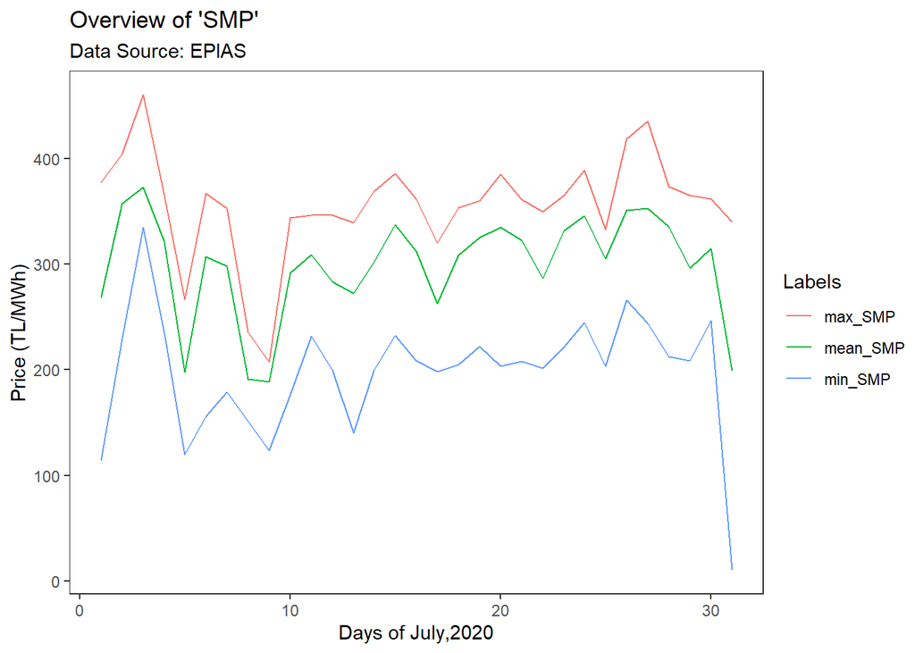

```r
plot_SMP %>%
  select(day, min_SMP, mean_SMP, max_SMP) %>%
  pivot_longer(.,-day) %>%
  ggplot(.,aes(x=day, y=value, color=name)) +
  geom_line() +
  theme_test() +
  labs(x="Days of July,2020", y="Price (TL/MWh)", color="Labels", title = "Overview of 'SMP'", subtitle = "Data Source: EPIAS") + theme(legend.position="right")
```

## Which datetime/s give the min or max ‘SMP’?

We can also investigate the datetimes which gives the min or max ‘SMP’ by following codes.

### For min ‘SMP’:

```r
prices %>%
  mutate(the_rank = rank(SMP., ties.method = "random")) %>%
  # There are three datetime gives the min 'SMP', so the_rank <= 3.
  filter(the_rank <= 3) %>%
  select(Date, SMP.)
```

```
##                  Date SMP.
## 1 2020-07-31 10:00:00   10
## 2 2020-07-31 11:00:00   10
## 3 2020-07-31 12:00:00   10
```

### For max ‘SMP’:

```r
prices %>%
  mutate(the_rank = rank(-SMP., ties.method = "random")) %>%
  # There are two datetime gives the max 'SMP', so the_rank <= 2.
  filter(the_rank <= 2) %>%
  select(Date, SMP.)
```

```
##                  Date SMP.
## 1 2020-07-03 14:00:00  460
## 2 2020-07-03 15:00:00  460
```

# References

- Data Source: [EPIAS/EXIST Transparency Platform](https://rapor.epias.com.tr/rapor/xhtml/ptfSmfListeleme.xhtml)

**End of the Assignment 2. Visit my [Progress Journal](https://pjournal.github.io/boun01-canaytore/)**